# Spirals in Jupyter

In jupyter, you must explicitly designate a cell as markdown - by default, cells are code.

First, we'll import numpy for mathematical calculations and matplotlib's pyplot for plotting.

```python
import numpy as np
import matplotlib.pyplot as plt
```

## Logarithmic Spiral

The logarithmic spiral has a polar equation of $$r = a e^{b\theta}$$ where $r$ is distance from the origin, $\theta$ is the angle from the x-axis, and $a$ and $b$ are constants. [Source](https://mathworld.wolfram.com/LogarithmicSpiral.html)

We can write the logarithmic spiral equation in Cartesian coordinates as: $$\begin{array} x &= r \cos\theta = a \cos\theta e^{b\theta}\\y &= r \sin\theta = a \sin\theta e^{b\theta}\end{array}$$

```python
# Define the angle of the spiral (polar coords)
# go around two full times (2*pi = one revolution)
theta = np.arange(0, 4 * np.pi, 0.01)
# Define the distance from the origin of the spiral
# Needs to have the same length as theta
# (get length of theta with theta.size,
#  and then divide 5 by that to get the increment)
r = np.arange(0, 5, 5/theta.size)
```

```python
# Now define x and y in cartesian coordinates
x = r * np.cos(theta)
y = r * np.sin(theta)
```

I'm less familiar with plotting in python than I am in R, but this code seems to work to generate the same type of plot:

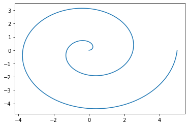

```python
# Define the axes
fig, ax = plt.subplots()
# Plot the line
ax.plot(x, y)
plt.show()
```

The same type of markdown formatting works in jupyter notebooks as well:

With markdown, I can create nice formatting with simple text -

# First header

## Second header

> A really nice quote

### Third header

```
some code from an unknown language
```

I also like the ability to make

1. numbered
2. lists

but sometimes you want to make a

- bulleted
- list

I have to put a blank line between the text and the list for the formatting to work just right. When in doubt, add a blank line :).